# Indicators of Heavy Traffic on I-94

In this project, we're going to analyze a dataset about the westbound traffic on the [I-94 Interstate highway](https://en.wikipedia.org/wiki/Interstate_94).

The goal of our analysis is to determine a few indicators of heavy traffic on I-94. These indicators can be weather type, time of the day, time of the week, etc.

# The I-94 Traffic Dataset

John Hogue made the dataset available that we'll be working with, and you can download it from the [UCI Machine Learning Repository](https://archive.ics.uci.edu/dataset/492/metro+interstate+traffic+volume).

## Variables Table

| Variable Name | Role | Type | Description | Units | Missing Values |
| --- | --- | --- | --- | --- | --- |
| holiday | Feature | Categorical | US National holidays plus regional holiday, Minnesota State Fair |  | no |
| temp | Feature | Continuous | Average temp in kelvin | Kelvin | no |
| rain_1h | Feature | Continuous | Amount in mm of rain that occurred in the hour | mm | no |
| snow_1h | Feature | Continuous | Amount in mm of snow that occurred in the hour | mm | no |
| clouds_all | Feature | Integer | Percentage of cloud cover | % | no |
| weather_main | Feature | Categorical | Short textual description of the current weather |  | no |
| weather_description | Feature | Categorical | Longer textual description of the current weather |  | no |
| date_time | Feature | Date | Hour of the data collected in local CST time |  | no |
| traffic_volume | Target | Integer | Hourly I-94 ATR 301 reported westbound traffic volume |  | no |

```python
import pandas as pd

i_94 = pd.read_csv("Metro_Interstate_Traffic_Volume.csv")
```

```python
i_94.info()
i_94.head()
```

```
<class 'pandas.DataFrame'>
RangeIndex: 48204 entries, 0 to 48203
Data columns (total 9 columns):
 #   Column               Non-Null Count  Dtype
---  ------               --------------  -----
 0   holiday              61 non-null     str
 1   temp                 48204 non-null  float64
 2   rain_1h              48204 non-null  float64
 3   snow_1h              48204 non-null  float64
 4   clouds_all           48204 non-null  int64
 5   weather_main         48204 non-null  str
 6   weather_description  48204 non-null  str
 7   date_time            48204 non-null  str
 8   traffic_volume       48204 non-null  int64
dtypes: float64(3), int64(2), str(4)
memory usage: 3.3 MB
```

|  | holiday | temp | rain_1h | snow_1h | clouds_all | weather_main | weather_description | date_time | traffic_volume |
| --- | --- | --- | --- | --- | --- | --- | --- | --- | --- |
| 0 | NaN | 288.28 | 0.0 | 0.0 | 40 | Clouds | scattered clouds | 2012-10-02 09:00:00 | 5545 |
| 1 | NaN | 289.36 | 0.0 | 0.0 | 75 | Clouds | broken clouds | 2012-10-02 10:00:00 | 4516 |
| 2 | NaN | 289.58 | 0.0 | 0.0 | 90 | Clouds | overcast clouds | 2012-10-02 11:00:00 | 4767 |
| 3 | NaN | 290.13 | 0.0 | 0.0 | 90 | Clouds | overcast clouds | 2012-10-02 12:00:00 | 5026 |
| 4 | NaN | 291.14 | 0.0 | 0.0 | 75 | Clouds | broken clouds | 2012-10-02 13:00:00 | 4918 |

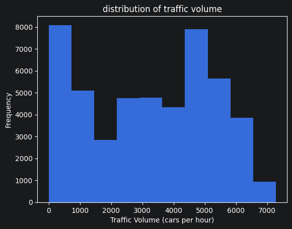

```python
import matplotlib.pyplot as plt
%matplotlib inline

i_94.traffic_volume.plot.hist(title = "distribution of traffic volume", xlabel= "Traffic Volume (cars per hour)",)
plt.show()
```

```python
i_94['traffic_volume'].describe()
```

```
count    48204.000000
mean      3259.818355
std       1986.860670
min          0.000000
25%       1193.000000
50%       3380.000000
75%       4933.000000
max       7280.000000
Name: traffic_volume, dtype: float64
```

The range of hourly traffic volume varied from 0 to 7,280 cars, with an average of 3,260 cars. About 25% of the time, there were only 1,193 cars or fewer passing the station each hour,this probably occurs during the night or when a road is under construction. However, about 25% of the time, the traffic volume was four times as much (4,933 cars or more). This observation gives our analysis an interesting direction: comparing daytime data with nighttime data.

## Traffic Volume: Day vs. Night

We are going to divide the dataset into 2:

- Daytime Data: hours from 7am to 7pm
- Nighttime Data: hours from 7pm to 7am

Twelve hours each as a starting point

```python
i_94['date_time'] = pd.to_datetime(i_94['date_time'])

day = i_94.copy()[(i_94['date_time'].dt.hour >= 7) & (i_94['date_time'].dt.hour<19)]
print(day.shape)

night = i_94.copy()[(i_94['date_time'].dt.hour >= 19) | (i_94['date_time'].dt.hour<7)]
print(night.shape)
```

```
(23877, 9)
(24327, 9)
```

```python
i_94.iloc[176:178]
```

|  | holiday | temp | rain_1h | snow_1h | clouds_all | weather_main | weather_description | date_time | traffic_volume |
| --- | --- | --- | --- | --- | --- | --- | --- | --- | --- |
| 176 | NaN | 281.17 | 0.0 | 0.0 | 90 | Clouds | overcast clouds | 2012-10-10 03:00:00 | 361 |
| 177 | NaN | 281.25 | 0.0 | 0.0 | 92 | Clear | sky is clear | 2012-10-10 06:00:00 | 5875 |

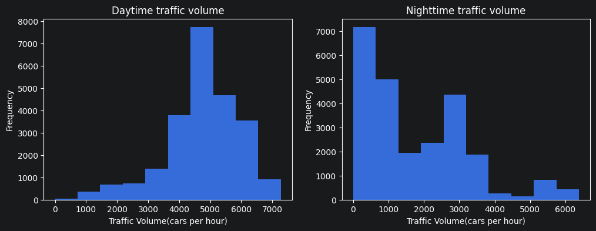

```python
plt.figure(figsize=(12,4))

plt.subplot(1,2,1)
day["traffic_volume"].plot.hist(title = 'Daytime traffic volume', xlabel = 'Traffic Volume(cars per hour)', ylabel = 'Frequency')

plt.subplot(1,2,2)
night['traffic_volume'].plot.hist(title = 'Nighttime traffic volume',xlabel = 'Traffic Volume(cars per hour)', ylabel = 'Frequency')
plt.show()
```

```python
day['traffic_volume'].describe()
```

```
count    23877.000000
mean      4762.047452
std       1174.546482
min          0.000000
25%       4252.000000
50%       4820.000000
75%       5559.000000
max       7280.000000
Name: traffic_volume, dtype: float64
```

```python
night['traffic_volume'].describe()
```

```
count    24327.000000
mean      1785.377441
std       1441.951197
min          0.000000
25%        530.000000
50%       1287.000000
75%       2819.000000
max       6386.000000
Name: traffic_volume, dtype: float64
```

The daytime histogram shows us that the highest frequency of car volume is in the range of 4,000 to 6,000 cars, and has consistent high traffic volumes with at least 4,200 cars passing through 75% of the time (25th percentile). The nighttime histogram shows us the traffic volume remains low, being concentrated on the front of the histogram, while the series describing tell us 75% of the time they theirs at least 530 cars passing through. Since we are concerned about finding the causes of high traffic volume, the focus shall be shifted to the daytime hours.

## Time Indicators

One of the possible indicators of heavy traffic is time. There might be more people on the road in a certain month, on a certain day, or at a certain time of day. We're going to look at a few line plots showing how the traffic volume changes according to the following:

- Month
- Day of the week
- Time of day

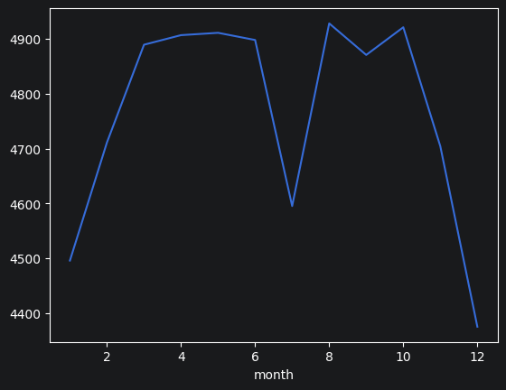

```python
day['month'] = day['date_time'].dt.month
by_month = day.groupby('month').mean(numeric_only=True)
by_month['traffic_volume'].plot.line()
plt.show()
```

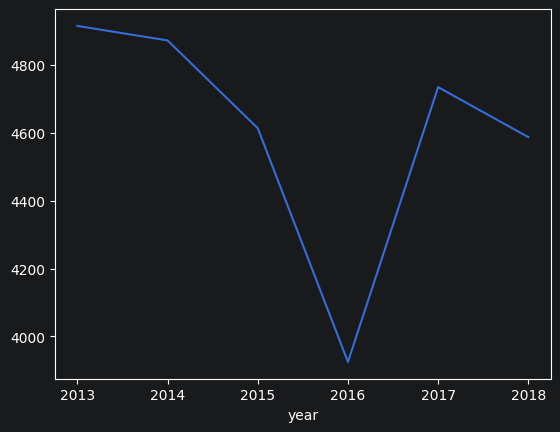

```python
day['year'] = day['date_time'].dt.year

only_july = day[day['month'] == 7]

only_july.groupby('year')['traffic_volume'].mean().plot.line()

plt.show()
```

Upon further investigation, we can see that by looking at the change of traffic for the month of July year over year, that July 2014 we begin a decrease in traffic volume. The lowest traffic volume occurring in July 2016 before rapidly increasing in 2017, to slowly begin to decrease again in 2018.

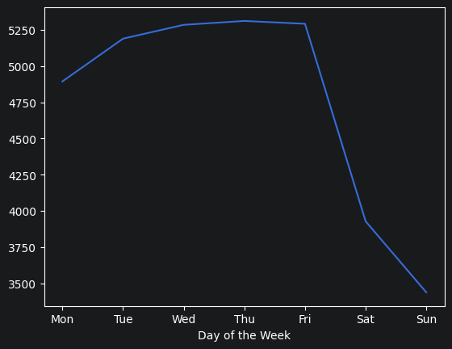

```python
day['dayofweek'] = day['date_time'].dt.dayofweek
by_dayofweek = day.groupby('dayofweek').mean(numeric_only=True)
by_dayofweek['traffic_volume'].plot.line() # 0 is Monday, 6 is Sunday
plt.xticks(range(7), ['Mon', 'Tue', 'Wed', 'Thu', 'Fri', 'Sat', 'Sun'])
plt.xlabel('Day of the Week')
plt.show()
```

From here we can see that, overall traffic volume is very heavy during the bussines days of the week. During the weekends though the traffic volume drops below 4,800.